# Live Session 11

Anna Frowein

November 19, 2016

# Set up file

Download required library and the data set

```r
#install.packages('fpp')
library(fpp)
data(ukcars)
```

## Question a

Plot the time series. Try to identify seasonal fluctuations and/or a trend.

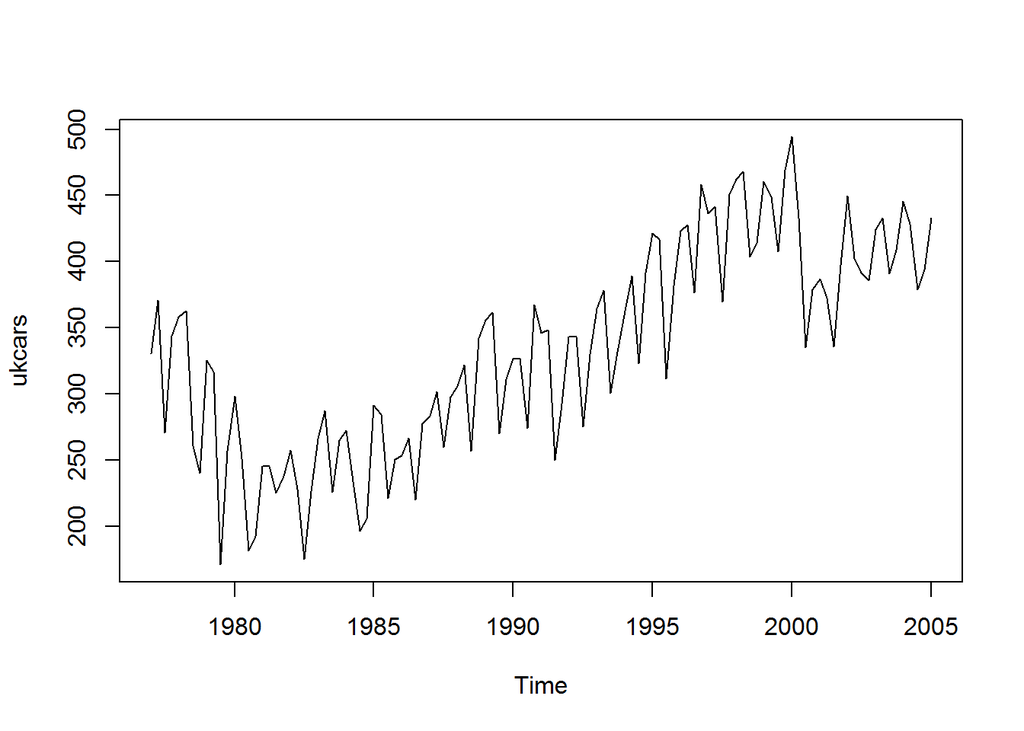

```r
plot(ukcars)
```

## Question B

Use a classical decomposition to calculate the trend-cycle and seasonal indices.

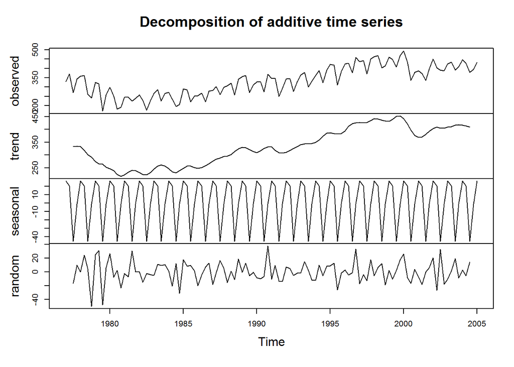

```r
fitd <- decompose(ukcars)
plot(fitd)
```

## Question C

Do the results support the graphical interpretation from findings made prior? The graphical results from Question B does support the initial observations made in Question A on the seasonality and growth trend.

## Question D

Compute and plot the seasonally adjusted data.

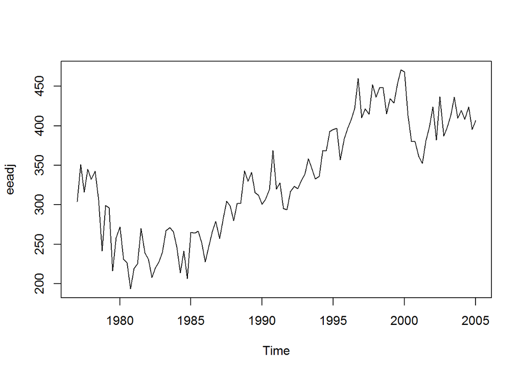

```r
eeadj <- seasadj(fitd)
plot(eeadj)
```

## Question E

Change one observation to be an outlier (e.g., add 500 to one observation), and recompute the seasonally adjusted data. What is the effect of the outlier?

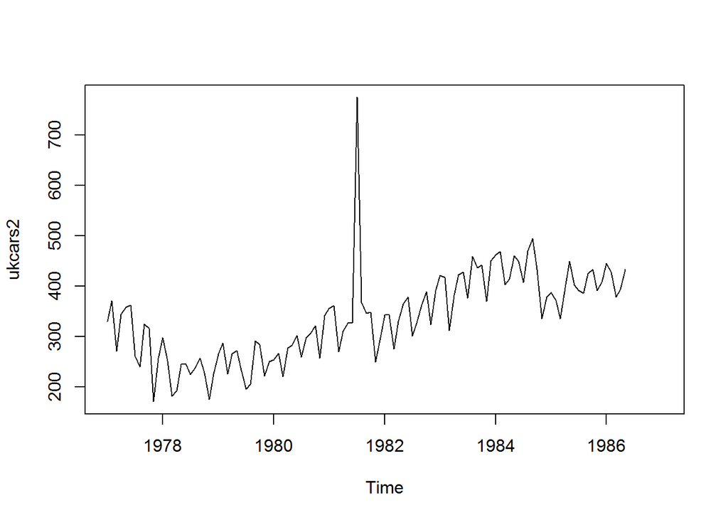

```r
ukcars2 <-ts(c(ukcars[1:54],ukcars[55]+500,ukcars[56:121] ),start=c(1977,1),frequency=12)
plot(ukcars2)
```

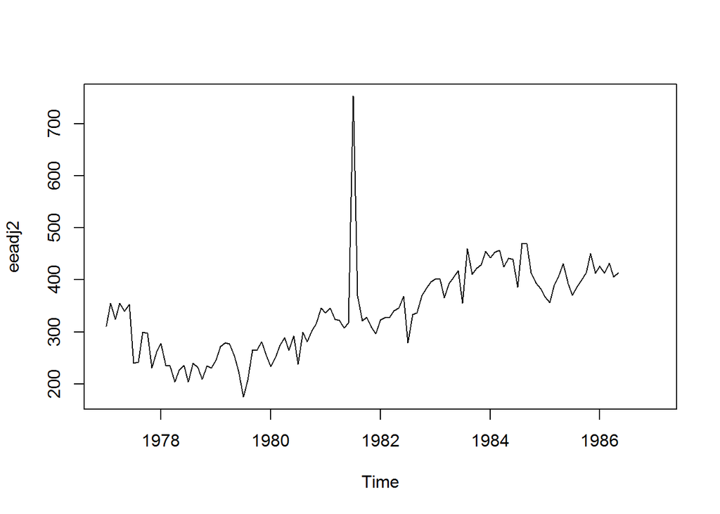

```r
eeadj2<-seasadj(decompose(ukcars2))
plot(eeadj2)
```

## Question F

Does it make any difference if the outlier is near the end rather than in the middle of the time series?

[figure not shown]

```r
ukcars3 <-ts(c(ukcars[1:119],ukcars[120]+500,ukcars[121] ),start=c(1977,1),frequency=12)
plot(ukcars3)
```

[figure not shown]

```r
eeadj3<-seasadj(decompose(ukcars3))
plot(eeadj3)
```

### Summary of findings

In the case of changing the data towards the end of series there seems to be less of an effect, perhaps due to the growth trend noted already. However, what I was expecting to see was a larger impact on the data which would cause the fit line to have a more sever slope if we assume a linear relationship in the data starting in the early 1980’s.

## Question G

Use STL to decompose the series

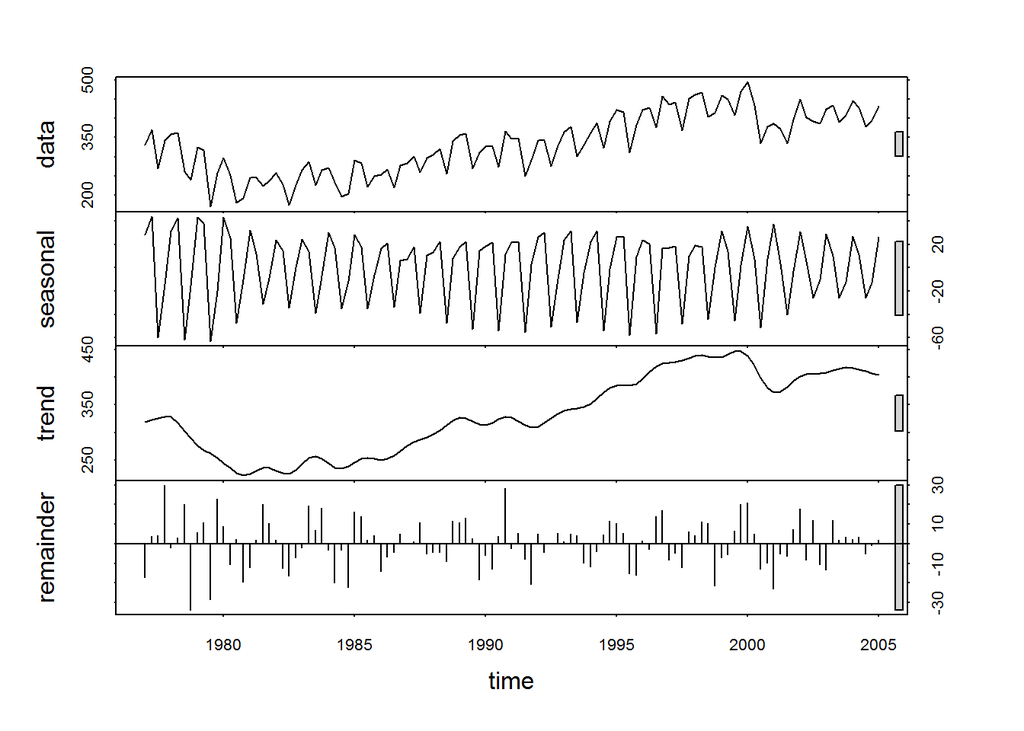

```r
fit <- stl(ukcars, s.window=5)
plot(fit)
```

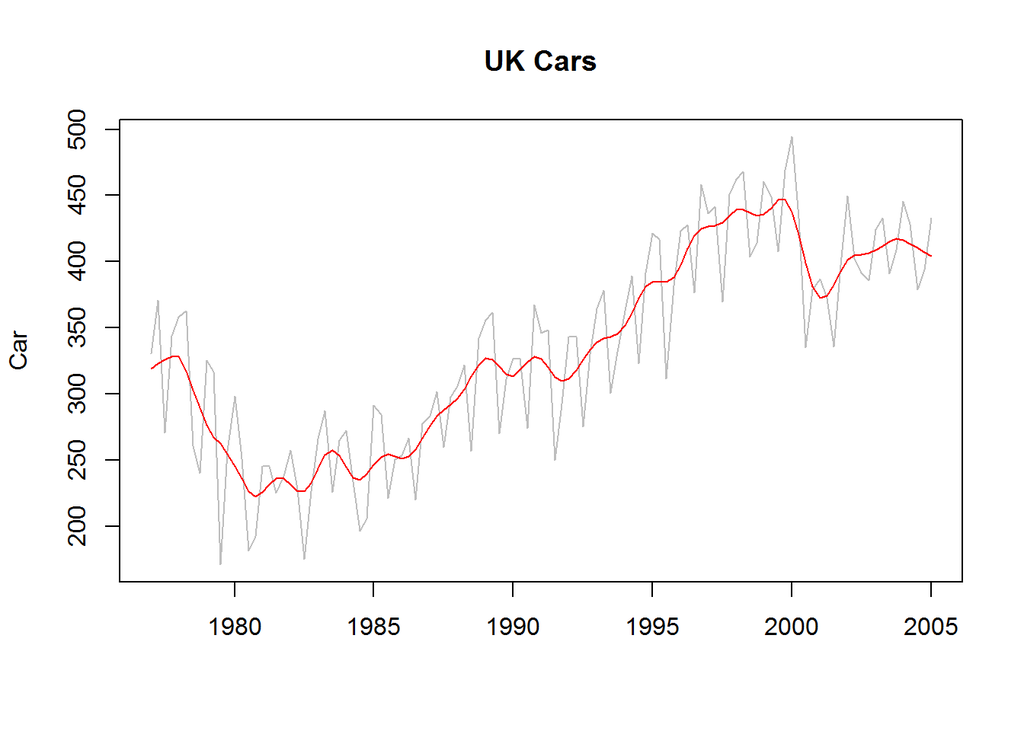

```r
plot(ukcars, col="gray",
     main="UK Cars",
     ylab="Car", xlab="")
lines(fit$time.series[,2],col="red",ylab="Trend")
```